# Estadistica para Astronomos

# Felipe Gran

#### Importamos paquetes importantes para el problema

```python
from sklearn.ensemble import RandomForestClassifier
from sklearn.preprocessing import LabelEncoder
from sklearn.grid_search import GridSearchCV
from sklearn.metrics import confusion_matrix
from sklearn.naive_bayes import GaussianNB
from sklearn import cross_validation
import matplotlib.pyplot as plt
from plotly.graph_objs import *
import plotly.plotly as py
from sklearn import svm
import numpy as np
import os

py.sign_in('fgran','vyvc5yqufy')
%pylab inline
```

```
WARNING: pylab import has clobbered these variables: ['Figure', 'cm', 'Annotation', 'grid']
`%matplotlib` prevents importing * from pylab and numpy
```

```python
os.chdir('/Users/apple/Dropbox/Magister/Cursos/Estadistica/2015-1/Examen/')
```

#### Importamos features de training desde el archivo de origen

```python
f1_train, f2_train, f3_train = np.genfromtxt('examen_dataset_p1.dat', usecols=(1,2,3), unpack=True)
label_train = np.genfromtxt('examen_dataset_p1.dat', usecols=(0), dtype=None)
```

#### Definimos valores a testear para nuestra clasificacion (K2)

```python
f1_K2 = 0.05
f2_K2 = 0.08
f3_K2 = 0.20
```

#### Convertimos los labels a numeros para que puedan ser usados en la clasificacion

```python
le = LabelEncoder()
le.fit(label_train)
```

```
LabelEncoder()
```

#### Vemos cuales son las clases que encontro

```python
print le.classes_
```

```
['DMCEP' 'EA' 'EB' 'EW' 'RRD']
```

#### Transformamos las variables a numeros

```python
labels = le.transform(label_train)
```

#### Vemos cuales son las clases que transformo, si son iguales debieran ser iguales los largos impresos

```python
print 'Largo de labels transformados iguales a los originales', np.sum( le.inverse_transform(labels) == label_train )
print 'Largo de los labels originales', len(label_train)
```

```
Largo de labels transformados iguales a los originales 522
Largo de los labels originales 522
```

#### Contamos si hay clases muy desbalanceadas en nuestro sample

```python
for i in xrange(len(le.classes_)):
    print le.inverse_transform(i), np.sum(labels == i)
```

```
DMCEP 94
EA 169
EB 145
EW 58
RRD 56
```

#### Hacemos que los datos tengan el formato correcto

```python
data = np.vstack((f1_train, f2_train, f3_train)).T
print data.shape, labels.shape
```

```
(522, 3) (522,)
```

#### Visualizamos los datos para tener una idea de como se ven (solo porque son 3 dimensiones!)

```python
from plotly.graph_objs import *

freq = Scatter3d(x=f1_train, y=f2_train, z=f3_train, name='Frecuencias de OGLE', mode='markers',
                 marker=Marker(color=labels*2, symbol='.', size=3, line=Line(width=1)), visible=True)

datos = Data([freq])
xaxis = XAxis(title='f1', autorange=True)
yaxis = YAxis(title=r'f2', autorange=True)
zaxis = ZAxis(title=r'f3', autorange=True)
layout = Layout(autosize=True, title = 'Diagrama de Petersen para estrellas variables de OGLE',
                scene=Scene(xaxis=xaxis, yaxis=yaxis, zaxis=zaxis))
figure = Figure(data=datos, layout=layout)
py.iplot(figure, filename='Petersen_3D_OGLE')
```

[interactive chart not shown]

### Primer modelo testeado: SVM Linear kernel

```python
####Para ello debemos tunear y verificar en una grilla que valores de la constante C definen el mejor clasificador SVM Lineal
```

```python
C_range = 10. ** np.arange(-5, 5)
param_grid = dict(C=C_range)
ss = cross_validation.StratifiedShuffleSplit(labels, 5, test_size = 0.25)
grid = GridSearchCV(svm.LinearSVC(), param_grid=param_grid, cv=ss)
grid.fit(data, labels)
print "El mejor clasificador es: ", grid.best_estimator_
```

```
El mejor clasificador es:  LinearSVC(C=0.10000000000000001, class_weight=None, dual=True,
     fit_intercept=True, intercept_scaling=1, loss='squared_hinge',
     max_iter=1000, multi_class='ovr', penalty='l2', random_state=None,
     tol=0.0001, verbose=0)
```

#### Sacamos los scores de cada modelo probado

```python
score_dict = grid.grid_scores_
scores = [x[1] for x in score_dict]
```

#### Ploteamos los valores de exactitud para cada modelo testeado

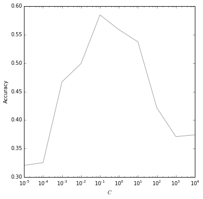

```python
plt.figure(figsize=(6,6))

plt.plot(C_range, scores, color='gray', alpha=0.8)
plt.xscale('log')
plt.xlabel(r'$C$')
plt.ylabel('Accuracy')

plt.show()
```

```python
print 'La maxima accuracy se logra con C = ', C_range[np.argmax(scores)], 'logrando un valor de Accuracy = ', np.max(scores)
```

```
La maxima accuracy se logra con C =  0.1 logrando un valor de Accuracy =  0.584732824427
```

```python
SVM_linear = svm.SVC(C=1, kernel='linear', probability=True)
```

#### Definimos la funcion para plotear la matriz de confusion

```python
def plot_confusion_matrix(cm, title='Confusion matrix', cmap=plt.cm.Blues):
    plt.imshow(cm, interpolation='nearest', cmap=cmap)
    plt.title(title)
    plt.colorbar()
    tick_marks = np.arange(len(labels))
    plt.xticks(range(5), le.classes_, rotation='vertical')
    plt.yticks(range(5), le.classes_)
    plt.tight_layout()
    plt.ylabel('True label')
    plt.xlabel('Predicted label')
```

#### Separamos nuestro sample en test y train set para hacer la matriz de confusion

```python
X_train, X_test, y_train, y_test = cross_validation.train_test_split(data, labels, test_size=1./3.)
y_pred = SVM_linear.fit(X_train, y_train).predict(X_test)
```

#### Printeamos la matriz de confusion

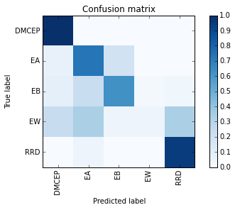

```python
cm = confusion_matrix(y_test, y_pred)
np.set_printoptions(precision=2)
cm_normalized = cm.astype('float') / cm.sum(axis=1)[:, np.newaxis]
plt.figure()
plot_confusion_matrix(cm_normalized)

plt.show()
```

```python
print('Confusion matrix')
print(cm_normalized)
```

```
Confusion matrix
[[ 1.    0.    0.    0.    0.  ]
 [ 0.08  0.73  0.19  0.    0.  ]
 [ 0.09  0.23  0.62  0.02  0.04]
 [ 0.24  0.33  0.05  0.05  0.33]
 [ 0.    0.05  0.    0.    0.95]]
```

#### Prediccion del clasificador SVM Linear para esta estrella

```python
predicted_class = SVM_linear.predict([f1_K2, f2_K2, f3_K2])
predicted_proba = SVM_linear.predict_proba([f1_K2, f2_K2, f3_K2])
print 'Prediccion para la estrella:', le.inverse_transform(predicted_class)[0]
print le.classes_
print np.round(predicted_proba,3)
```

```
Prediccion para la estrella: EB
['DMCEP' 'EA' 'EB' 'EW' 'RRD']
[[ 0.07  0.33  0.55  0.05  0.  ]]
```

### Probemos ahora con SVM con un RBF kernel

#### Volvemos a hacer la grilla de parametros a los cuales debe ajustar los datos

```python
C_range = 10. ** np.arange(-4, 4)
gamma_range = 10. ** np.arange(-4, 4)
param_grid = dict(gamma=gamma_range, C=C_range)
grid = GridSearchCV(svm.SVC(kernel = "rbf"), param_grid=param_grid, cv=ss)
grid.fit (data, labels)
print "El mejor clasificador es: ", grid.best_estimator_

score_dict = grid.grid_scores_
scores = [x[1] for x in score_dict]
scores = np.array(scores).reshape(len(C_range), len(gamma_range))
```

```
El mejor clasificador es:  SVC(C=1000.0, cache_size=200, class_weight=None, coef0=0.0, degree=3,
  gamma=0.10000000000000001, kernel='rbf', max_iter=-1, probability=False,
  random_state=None, shrinking=True, tol=0.001, verbose=False)
```

#### Ploteamos los valores de exactitud para cada modelo testeado

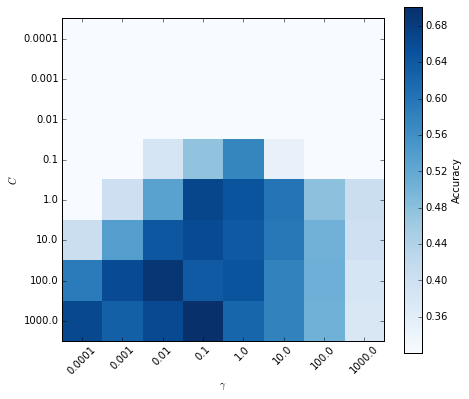

```python
plt.figure(figsize=(7, 6))

plt.subplots_adjust(left=0.15, right=0.95, bottom=0.15, top=0.95)
plt.imshow(scores, interpolation='nearest', cmap=plt.cm.Blues)
plt.xlabel(r'$\gamma$')
plt.ylabel(r'$C$')
cb = plt.colorbar()
cb.set_label('Accuracy')
plt.xticks(np.arange(len(gamma_range)), gamma_range, rotation=45)
plt.yticks(np.arange(len(C_range)), C_range)

plt.show()
```

```python
SVM_rbf = svm.SVC(C=1, gamma=0.1, kernel='rbf', probability=True)
```

#### Separamos nuestro sample en test y train set para hacer la matriz de confusion

```python
X_train, X_test, y_train, y_test = cross_validation.train_test_split(data, labels, test_size=1./3.)
y_pred = SVM_rbf.fit(X_train, y_train).predict(X_test)
```

#### Printeamos la matriz de confusion

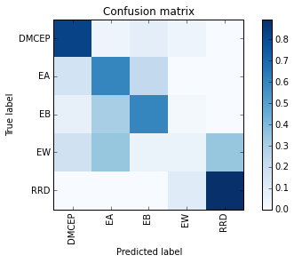

```python
cm = confusion_matrix(y_test, y_pred)
np.set_printoptions(precision=2)
cm_normalized = cm.astype('float') / cm.sum(axis=1)[:, np.newaxis]
plt.figure()
plot_confusion_matrix(cm_normalized)

plt.show()
```

```python
print('Confusion matrix')
print(cm_normalized)
```

```
Confusion matrix
[[ 0.83  0.04  0.09  0.04  0.  ]
 [ 0.17  0.6   0.23  0.    0.  ]
 [ 0.07  0.31  0.6   0.02  0.  ]
 [ 0.18  0.35  0.06  0.06  0.35]
 [ 0.    0.    0.    0.11  0.89]]
```

```python
predicted_class = SVM_rbf.predict([f1_K2, f2_K2, f3_K2])
predicted_proba = SVM_rbf.predict_proba([f1_K2, f2_K2, f3_K2])
print 'Prediccion para la estrella:', le.inverse_transform(predicted_class)[0]
print le.classes_
print np.round(predicted_proba,3)
```

```
Prediccion para la estrella: EB
['DMCEP' 'EA' 'EB' 'EW' 'RRD']
[[ 0.05  0.25  0.63  0.08  0.  ]]
```

### Probamos ahora GNB para clasificar

```python
X_train, X_test, y_train, y_test = cross_validation.train_test_split(data, labels, test_size=1./3.)

GNB = GaussianNB()
GNB.fit(X_train, y_train)
y_pred = GNB.predict(X_test)
```

#### Printeamos la matriz de confusion

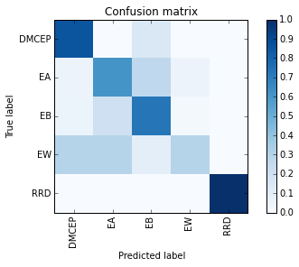

```python
cm = confusion_matrix(y_test, y_pred)
np.set_printoptions(precision=2)
cm_normalized = cm.astype('float') / cm.sum(axis=1)[:, np.newaxis]
plt.figure()
plot_confusion_matrix(cm_normalized)

plt.show()
```

```python
print('Confusion matrix')
print(cm_normalized)
```

```
Confusion matrix
[[ 0.86  0.    0.14  0.    0.  ]
 [ 0.06  0.62  0.27  0.06  0.  ]
 [ 0.05  0.2   0.73  0.02  0.  ]
 [ 0.3   0.3   0.1   0.3   0.  ]
 [ 0.    0.    0.    0.    1.  ]]
```

```python
predicted_class = GNB.predict([f1_K2, f2_K2, f3_K2])
predicted_prob = GNB.predict_proba([f1_K2, f2_K2, f3_K2])[0]
print 'Prediccion para la estrella:', le.inverse_transform(predicted_class)[0]
print le.classes_
print np.round(predicted_prob,3)
```

```
Prediccion para la estrella: EB
['DMCEP' 'EA' 'EB' 'EW' 'RRD']
[ 0.    0.21  0.76  0.03  0.  ]
```

### Probamos ahora con el algoritmo de Random Forests

```python
X_train, X_test, y_train, y_test = cross_validation.train_test_split(data, labels, test_size=1./3.)

RF = RandomForestClassifier(n_estimators=20)

param_grid = {"max_depth": [3, None],
              "max_features": [1, 2, 3],
              "min_samples_split": [1, 3, 10],
              "min_samples_leaf": [1, 3, 10],
              "bootstrap": [True, False],
              "criterion": ["gini", "entropy"]}

ss = cross_validation.StratifiedShuffleSplit(labels, 5, test_size = 0.25)
grid = GridSearchCV(RF, param_grid=param_grid, cv=ss)
grid.fit(data, labels);

print grid.best_estimator_
```

```
RandomForestClassifier(bootstrap=True, class_weight=None, criterion='gini',
            max_depth=None, max_features=2, max_leaf_nodes=None,
            min_samples_leaf=3, min_samples_split=1,
            min_weight_fraction_leaf=0.0, n_estimators=20, n_jobs=1,
            oob_score=False, random_state=None, verbose=0,
            warm_start=False)
```

```python
RF = RandomForestClassifier(bootstrap=False, class_weight=None, criterion='gini',
            max_depth=None, max_features=1, max_leaf_nodes=None,
            min_samples_leaf=3, min_samples_split=3,
            min_weight_fraction_leaf=0.0, n_estimators=20, n_jobs=1,
            oob_score=False, random_state=None, verbose=0,
            warm_start=False)
```

```python
RF.fit(X_train, y_train)
y_pred = RF.predict(X_test)
```

#### Printeamos la matriz de confusion

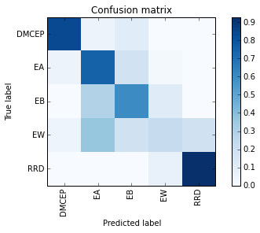

```python
cm = confusion_matrix(y_test, y_pred)
np.set_printoptions(precision=2)
cm_normalized = cm.astype('float') / cm.sum(axis=1)[:, np.newaxis]
plt.figure()
plot_confusion_matrix(cm_normalized)

plt.show()
```

```python
print('Confusion matrix')
print(cm_normalized)
```

```
Confusion matrix
[[ 0.84  0.05  0.11  0.    0.  ]
 [ 0.05  0.75  0.18  0.02  0.  ]
 [ 0.    0.29  0.6   0.11  0.  ]
 [ 0.05  0.36  0.18  0.23  0.18]
 [ 0.    0.    0.    0.07  0.93]]
```

```python
#Prediccion del clasificador SVM Linear para esta estrella
predicted_class = RF.predict([f1_K2, f2_K2, f3_K2])
predicted_prob = RF.predict_proba([f1_K2, f2_K2, f3_K2])[0]
print 'Prediccion para la estrella:', le.inverse_transform(predicted_class)[0]
print le.classes_
print np.round(predicted_prob,3)
```

```
Prediccion para la estrella: EB
['DMCEP' 'EA' 'EB' 'EW' 'RRD']
[ 0.    0.01  0.99  0.    0.  ]
```

### Se revisan las matrices de confusion y las de RF y SVM rbf nos parecen bastante buenas, por lo que decidimos hacer otra prueba

```python
from sklearn.metrics import accuracy_score

ss = cross_validation.StratifiedShuffleSplit(labels, 10, test_size = 1./3.)
scores_RF = cross_validation.cross_val_score(RF, data, labels, cv=ss)
scores_SVM = cross_validation.cross_val_score(SVM_rbf, data, labels, cv=ss)
print "RF Accuracy = ", scores_RF.mean(), "+-", scores_RF.std()
print "SVM Accuracy = ", scores_SVM.mean(), "+-", scores_SVM.std()
```

```
RF Accuracy =  0.657225433526 +- 0.0332105951959
SVM Accuracy =  0.656647398844 +- 0.0202229545486
```

#### Veamos si esta realmente en la zona de las EB en el espacio de frecuencias $f_1$, $f_2$ y $f_3$

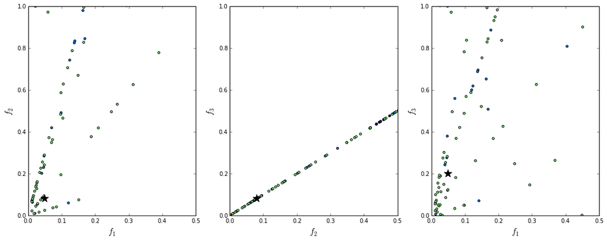

```python
plt.figure(figsize=(15,6))

plt.subplot(131)
plt.scatter(f1_train, f2_train, marker='.', c=labels, s=60)
plt.scatter(f1_K2, f2_K2, marker='*', color='k', s=200)
plt.xlim(0,0.5)
plt.ylim(0,1)
plt.xlabel(r'$f_1$', size=15)
plt.ylabel(r'$f_2$', size=15)

plt.subplot(132)
plt.scatter(f2_train, f2_train, marker='.', c=labels, s=60)
plt.scatter(f2_K2, f2_K2, marker='*', color='k', s=200)
plt.xlim(0,0.5)
plt.ylim(0,1)
plt.xlabel(r'$f_2$', size=15)
plt.ylabel(r'$f_3$', size=15)

plt.subplot(133)
plt.scatter(f1_train, f3_train, marker='.', c=labels, s=60)
plt.scatter(f1_K2, f3_K2, marker='*', color='k', s=200)
plt.xlim(0,0.5)
plt.ylim(0,1)
plt.xlabel(r'$f_1$', size=15)
plt.ylabel(r'$f_3$', size=15)

plt.tight_layout()
plt.show()
```

#### Vemos que nuestra estrella de K2 esta efectivamente en el area de las EB en el diagrama de Petersen impostor (ya que es $P_1$/$P_2$)

#### Como vemos responde efectivamente a nuestro juicio y podriamos haberla clasificado visualmente del mismo tipo si fuera el caso.

#### Una mejor clasificacion se daria considerando features que tengan relacion con la forma de la curva de luz (parametros de Fourier o amplitudes de los transitos/eclipses por ejemplo). Esto perimitia diferencias bastante entre EA, EB y EW, que es donde los clasificadores que entrenamos nosotros fallan.